# ANOVA exercise

Lucia Caroli

2025-11-16

## Loading the data

The dataset contains records for 287 individuals of known parentage, where larval host and maternal host plants were recorded, along with development time, growth rate and adult weight of the individuals. Hosts are plants of Barbarea (Bb) or Berteroa (Bt) genus.

```r
df = read.csv("C:/Users/lu1280ca/Work Folders/Downloads/butterflies.csv", sep = ",")
df$MaternalHost = paste0(df$MaternalHost, "M")
df$LarvalHost = paste0(df$LarvalHost, "L")
```

## ANOVA models

Test the effect of LarvalHost, MaternalHost and their interaction on the three response variables (DevelopmentTime, GrowthRate, AdultWeight).

```r
aw = lm(df$AdultWeight~df$LarvalHost*df$MaternalHost)
gr = lm(df$GrowthRate~df$LarvalHost*df$MaternalHost)
dt = lm(df$DevelopmentTime~df$LarvalHost*df$MaternalHost)
```

## Assumptions

Check that assumptions are met:

- Residuals are normally distributed

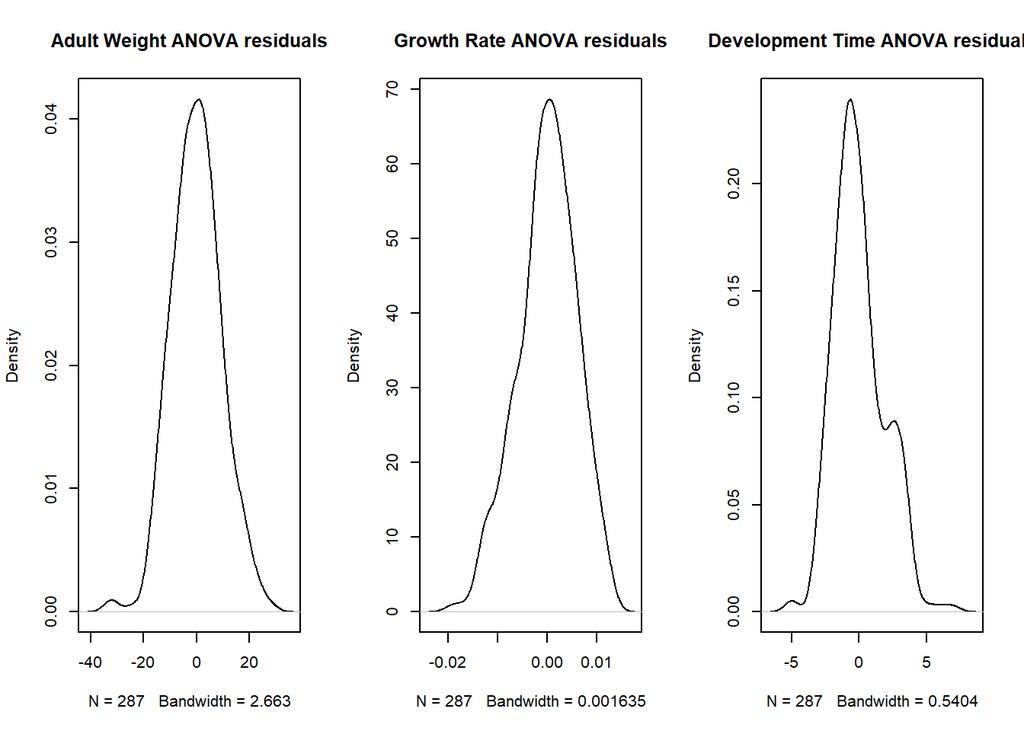

```r
par(mfrow=c(1,3))
plot(density(aw$residuals),main="Adult Weight ANOVA residuals")
plot(density(gr$residuals),main="Growth Rate ANOVA residuals")
plot(density(dt$residuals), main="Development Time ANOVA residuals")
```

The residuals of dt do not appear to be normally distributed. The curve has two humps.

- Homogeneity of variance across the groups

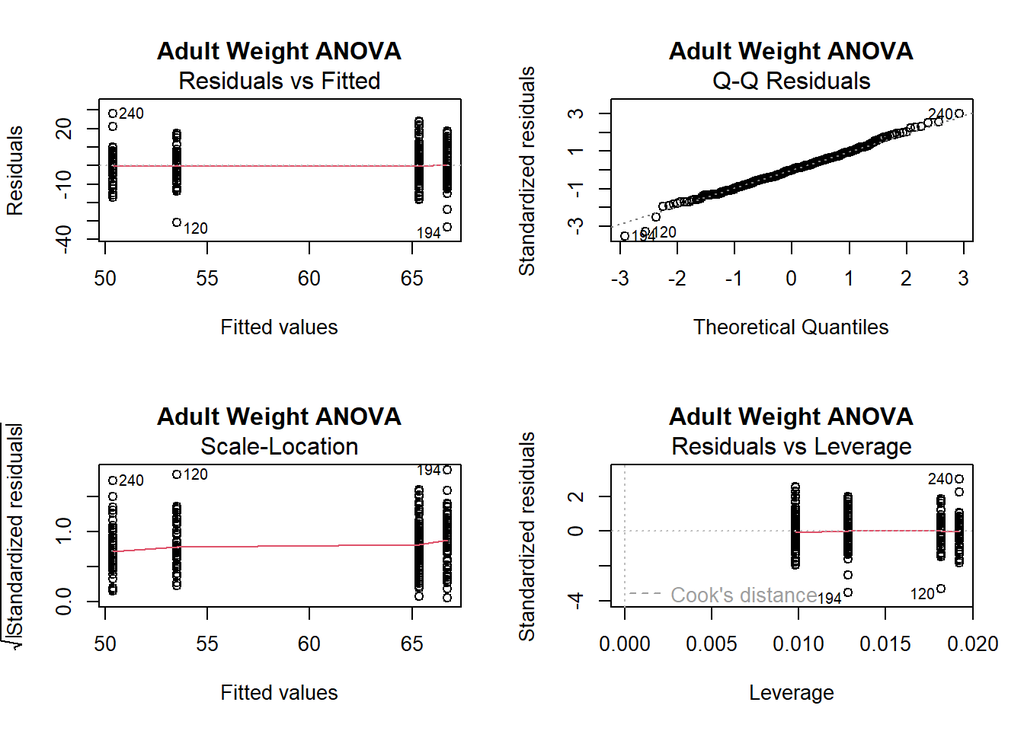

```r
par(mfrow=c(2,2))
plot(aw,main="Adult Weight ANOVA")
```

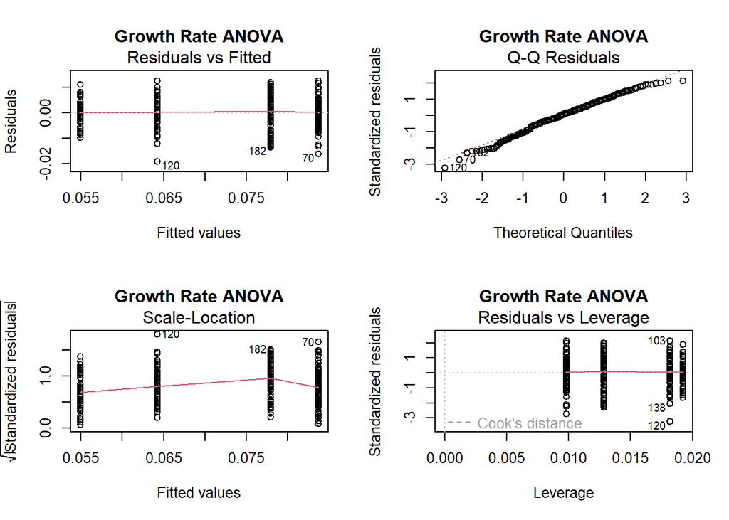

```r
plot(gr,main="Growth Rate ANOVA")
```

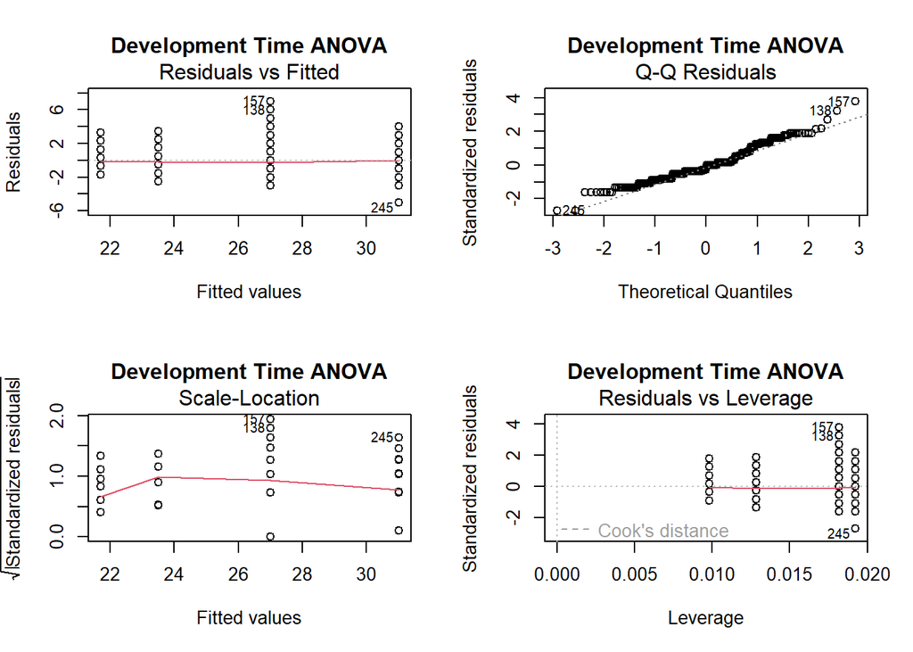

```r
plot(dt, main="Development Time ANOVA")
```

In the ANOVA for Development time (dt), looking at the fitted vs residuals plot, the variance does not look homogeneous, as the vertical variation is not equally “spread”. Taking the log() and sqrt() does not “fix” the appearance of the data (i.e., the two humps remain). Development time probably needs to be transformed in some other way in order to be analysed with ANOVA.

## ANOVA tables and summaries

```r
anova(aw)
```

```
## Analysis of Variance Table
##
## Response: df$AdultWeight
##                                Df  Sum Sq Mean Sq  F value Pr(>F)
## df$LarvalHost                   1 13086.0 13086.0 145.6248 <2e-16 ***
## df$MaternalHost                 1     7.5     7.5   0.0833 0.7731
## df$LarvalHost:df$MaternalHost   1   336.7   336.7   3.7471 0.0539 .
## Residuals                     283 25430.7    89.9
## ---
## Signif. codes:  0 '***' 0.001 '**' 0.01 '*' 0.05 '.' 0.1 ' ' 1
```

```r
summary(aw)
```

```
##
## Call:
## lm(formula = df$AdultWeight ~ df$LarvalHost * df$MaternalHost)
##
## Residuals:
##     Min      1Q  Median      3Q     Max
## -33.324  -6.214  -0.024   6.084  28.123
##
## Coefficients:
##                                     Estimate Std. Error t value Pr(>|t|)
## (Intercept)                          65.3549     0.9386  69.629  < 2e-16 ***
## df$LarvalHostBtL                    -11.8513     1.5858  -7.473 9.81e-13 ***
## df$MaternalHostBtM                    1.3695     1.4259   0.960   0.3377
## df$LarvalHostBtL:df$MaternalHostBtM  -4.4962     2.3227  -1.936   0.0539 .
## ---
## Signif. codes:  0 '***' 0.001 '**' 0.01 '*' 0.05 '.' 0.1 ' ' 1
##
## Residual standard error: 9.48 on 283 degrees of freedom
## Multiple R-squared:  0.3456, Adjusted R-squared:  0.3387
## F-statistic: 49.82 on 3 and 283 DF,  p-value: < 2.2e-16
```

```r
anova(gr)
```

```
## Analysis of Variance Table
##
## Response: df$GrowthRate
##                                Df    Sum Sq   Mean Sq  F value Pr(>F)
## df$LarvalHost                   1 0.0310561 0.0310561 875.4154 <2e-16 ***
## df$MaternalHost                 1 0.0035847 0.0035847 101.0475 <2e-16 ***
## df$LarvalHost:df$MaternalHost   1 0.0002080 0.0002080   5.8621 0.0161 *
## Residuals                     283 0.0100397 0.0000355
## ---
## Signif. codes:  0 '***' 0.001 '**' 0.01 '*' 0.05 '.' 0.1 ' ' 1
```

```r
summary(gr)
```

```
##
## Call:
## lm(formula = df$GrowthRate ~ df$LarvalHost * df$MaternalHost)
##
## Residuals:
##        Min         1Q     Median         3Q        Max
## -0.0191549 -0.0034058  0.0004718  0.0041452  0.0126051
##
## Coefficients:
##                                       Estimate Std. Error t value Pr(>|t|)
## (Intercept)                          0.0837158  0.0005897 141.952  < 2e-16 ***
## df$LarvalHostBtL                    -0.0194909  0.0009964 -19.561  < 2e-16 ***
## df$MaternalHostBtM                  -0.0057776  0.0008959  -6.449 4.85e-10 ***
## df$LarvalHostBtL:df$MaternalHostBtM -0.0035335  0.0014594  -2.421   0.0161 *
## ---
## Signif. codes:  0 '***' 0.001 '**' 0.01 '*' 0.05 '.' 0.1 ' ' 1
##
## Residual standard error: 0.005956 on 283 degrees of freedom
## Multiple R-squared:  0.7763, Adjusted R-squared:  0.774
## F-statistic: 327.4 on 3 and 283 DF,  p-value: < 2.2e-16
```

## Plots

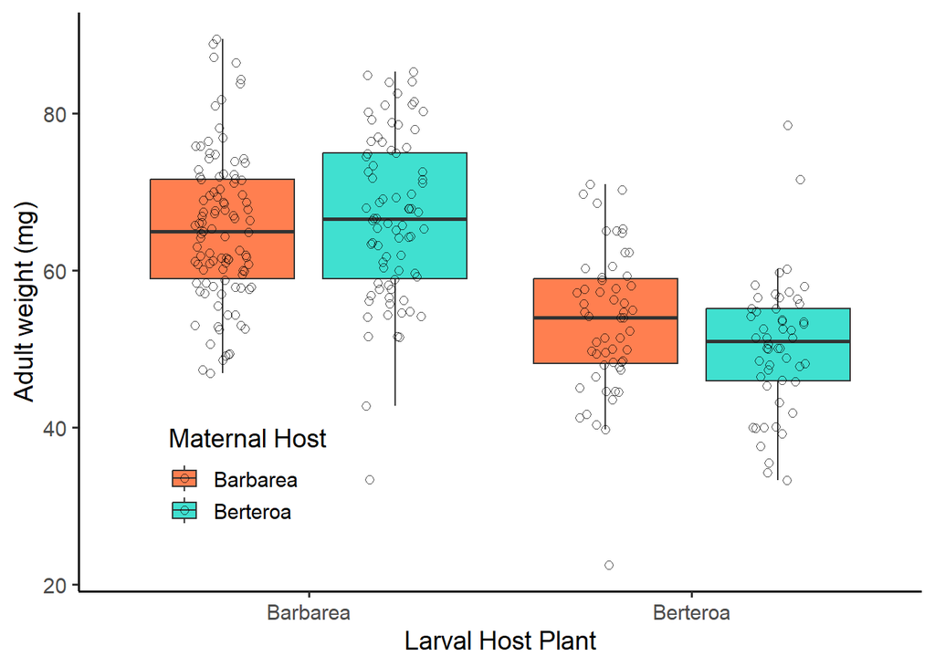

```r
ggplot(df, aes(x = LarvalHost,
               y = AdultWeight,
               fill = MaternalHost,
               )) +
  geom_boxplot(position = position_dodge(width = 0.9),
               outlier.shape = NA) +
  geom_jitter(position = position_jitterdodge(
                 jitter.width = 0.15,
                 jitter.height = 0,
                 dodge.width = 0.9),
              alpha = 0.7,
              size = 2,
              shape = 1) +
  scale_fill_manual(values = c("coral", "turquoise"),
                    labels = c("Barbarea", "Berteroa")) +
  scale_x_discrete(labels = c("Barbarea", "Berteroa"))+
  guides(fill = guide_legend(title = "Maternal Host"),
         color = "none") +
  theme_classic(base_size = 14) +
  theme(legend.position = c(0.20, 0.20)) +
  labs(
    x = "Larval Host Plant",
    y = "Adult weight (mg)"
  )
```

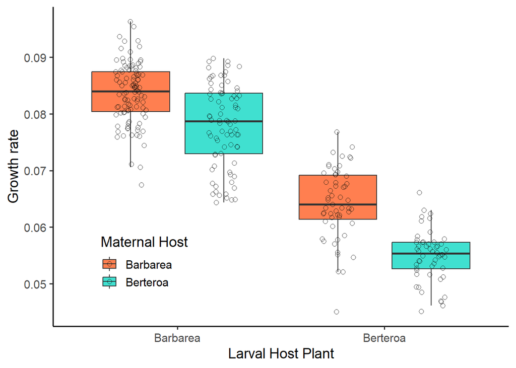

```r
ggplot(df, aes(x = LarvalHost,
               y = GrowthRate,
               fill = MaternalHost,
               )) +
  geom_boxplot(position = position_dodge(width = 0.9),
               outlier.shape = NA) +
  geom_jitter(position = position_jitterdodge(
                 jitter.width = 0.15,
                 jitter.height = 0,
                 dodge.width = 0.9),
              alpha = 0.7,
              size = 2,
              shape = 1) +
  scale_fill_manual(values = c("coral", "turquoise"),
                    labels = c("Barbarea", "Berteroa")) +
  scale_x_discrete(labels = c("Barbarea", "Berteroa"))+
  guides(fill = guide_legend(title = "Maternal Host"),
         color = "none") +
  theme_classic(base_size = 14) +
  theme(legend.position = c(0.20, 0.20)) +
  labs(
    x = "Larval Host Plant",
    y = "Growth rate"
  )
```

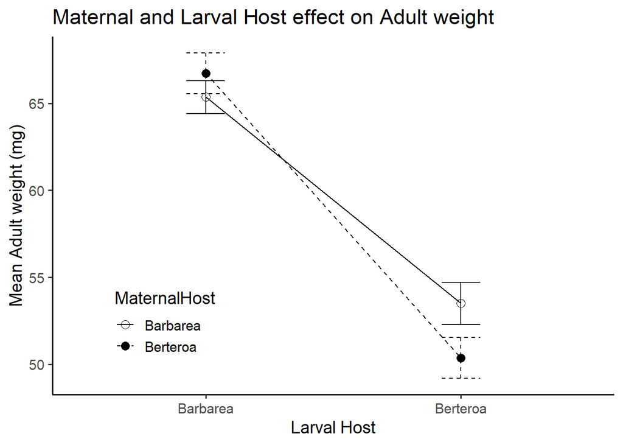

```r
means_aw = df %>%
  group_by(LarvalHost, MaternalHost) %>%
  summarise(
    mean = mean(AdultWeight, na.rm = TRUE),
    se   = sd(AdultWeight, na.rm = TRUE) / sqrt(n())
  )

ggplot(means_aw, aes(x = LarvalHost,
                  y = mean,
                  linetype = MaternalHost,
                  group = MaternalHost,
                  shape = MaternalHost)) +
  geom_point(size = 3)+
  scale_shape_manual(values = c(1,19))+
  geom_line() +
  geom_errorbar(aes(ymin = mean - se, ymax = mean + se),
                width = 0.15) +
  scale_x_discrete(labels = c("Barbarea", "Berteroa"))+
  scale_shape_manual(values = c(1, 19),
                     labels = c("Barbarea", "Berteroa")) +
  scale_linetype_manual(values = c("solid", "dashed"),
                        labels = c("Barbarea", "Berteroa")) +
  theme_classic(base_size = 14) +
  theme(legend.position = c(0.20, 0.20))+
  labs(
    title = "Maternal and Larval Host effect on Adult weight",
    x = "Larval Host",
    y = "Mean Adult weight (mg)",
    color = "Maternal Host"
  )
```

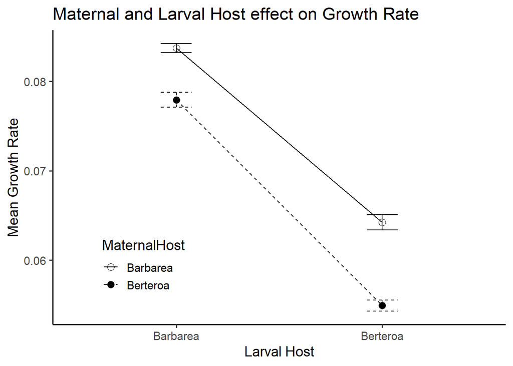

```r
means_gr = df %>%
  group_by(LarvalHost, MaternalHost) %>%
  summarise(
    mean = mean(GrowthRate, na.rm = TRUE),
    se   = sd(GrowthRate, na.rm = TRUE) / sqrt(n())
  )
ggplot(means_gr, aes(x = LarvalHost,
                  y = mean,
                  linetype = MaternalHost,
                  group = MaternalHost,
                  shape = MaternalHost)) +
  geom_point(size = 3)+
  scale_shape_manual(values = c(1,19))+
  geom_line() +
  geom_errorbar(aes(ymin = mean - se, ymax = mean + se),
                width = 0.15) +
  theme_classic(base_size = 14) +
  scale_x_discrete(labels = c("Barbarea", "Berteroa"))+
  theme(legend.position = c(0.20, 0.20))+
  scale_shape_manual(values = c(1, 19),
                     labels = c("Barbarea", "Berteroa")) +
  scale_linetype_manual(values = c("solid", "dashed"),
                        labels = c("Barbarea", "Berteroa")) +
  labs(
    title = "Maternal and Larval Host effect on Growth Rate",
    x = "Larval Host",
    y = "Mean Growth Rate",
    color = "Maternal Host"
  )
```